# Pixar Film Analysis Report

Emir Asaf Bas & Seyda Nur Zencirci & Tayyar Berke Tavlan & Natoli Hunduma Legesse

2026-04-20

## 1. Introduction

In this project, we analyze the Pixar Film Ratings dataset to understand the relationship between critical acclaim and commercial success. Our objective is to explore how audience perceptions and critic scores have evolved over the years and their impact on the studio’s financial performance.

The report is organised in four stages: **Data Cleaning and Preparation**, **Exploratory Data Analysis**, **Modeling**, and **Summary and Reflection**.

## 2. Data Cleaning and Preparation

### 2.1. Loading and Merging the Datasets

In this step, we load the three main tables from the `pixarfilms` package: `pixar_films`, `pixar_ratings`, and `pixar_box_office`. To conduct a comprehensive analysis, we merge these datasets into a single “Master Dataset” using the common `film` column as our primary key.

Before merging, we inspect each dataset individually. `pixar_films` contains 27 films with basic information: film number, name, release date, runtime, and rating. `public_response` contains 24 rows with critic scores from Rotten Tomatoes, Metacritic, CinemaScore, and Critics’ Choice. `box_office` also contains 24 rows with budget and revenue data.

We noticed that both `public_response` and `box_office` have only 24 rows compared to 27 in `pixar_films`. In addition, the 24th row in both tables (*Luca*) is present but entirely empty. As a result, **4 films** have no scores or financial data in this version of the package: *Luca* (2021), *Turning Red* (2022), *Lightyear* (2022), and a 2023 entry whose title is missing (`NA`). These are the most recent films at the time the package data was compiled; *Luca* and *Turning Red* were also released directly on Disney+, so they have no theatrical box office figures.

We also notice that `number` is stored as text (`chr`) in `pixar_films` and will need to be fixed after merging. We use `film` as the join key since it appears in all three tables.

```r
# Loading original datasets from the package
pixar_films <- pixarfilms::pixar_films
pixar_ratings <- pixarfilms::public_response
pixar_box_office <- pixarfilms::box_office

# Inspecting each dataset before merging
str(pixar_films)
```

```
## tibble [27 × 5] (S3: tbl_df/tbl/data.frame)
##  $ number      : chr [1:27] "1" "2" "3" "4" ...
##  $ film        : chr [1:27] "Toy Story" "A Bug's Life" "Toy Story 2" "Monsters, Inc." ...
##  $ release_date: Date[1:27], format: "1995-11-22" "1998-11-25" ...
##  $ run_time    : num [1:27] 81 95 92 92 100 115 117 111 98 96 ...
##  $ film_rating : chr [1:27] "G" "G" "G" "G" ...
```

```r
str(pixar_ratings)
```

```
## tibble [24 × 5] (S3: tbl_df/tbl/data.frame)
##  $ film           : chr [1:24] "Toy Story" "A Bug's Life" "Toy Story 2" "Monsters, Inc." ...
##  $ rotten_tomatoes: num [1:24] 100 92 100 96 99 97 74 96 95 98 ...
##  $ metacritic     : num [1:24] 95 77 88 79 90 90 73 96 95 88 ...
##  $ cinema_score   : chr [1:24] "A" "A" "A+" "A+" ...
##  $ critics_choice : num [1:24] NA NA 100 92 97 88 89 91 90 95 ...
```

```r
str(pixar_box_office)
```

```
## tibble [24 × 5] (S3: tbl_df/tbl/data.frame)
##  $ film                : chr [1:24] "Toy Story" "A Bug's Life" "Toy Story 2" "Monsters, Inc." ...
##  $ budget              : num [1:24] 3.00e+07 1.20e+08 9.00e+07 1.15e+08 9.40e+07 9.20e+07 1.20e+08 1.50e+08 1.80e+08 1.75e+08 ...
##  $ box_office_us_canada: num [1:24] 1.92e+08 1.63e+08 2.46e+08 2.90e+08 3.40e+08 ...
##  $ box_office_other    : num [1:24] 1.82e+08 2.00e+08 2.52e+08 3.42e+08 5.31e+08 ...
##  $ box_office_worldwide: num [1:24] 3.74e+08 3.63e+08 4.97e+08 6.32e+08 8.71e+08 ...
```

After merging, the `master dataset` has 27 rows and 13 columns as expected. The 4 films without scores or box office data remain in the dataset with `NA` values — this is intentional since we used `left_join`, which keeps all rows from `pixar_films` regardless of whether a match exists in the other tables.

```r
# Merging datasets using left_join to preserve the main film list
pixar_master <- pixar_films %>%
  left_join(pixar_ratings, by = "film") %>%
  left_join(pixar_box_office, by = "film")

# Verifying the merged structure
str(pixar_master)
```

```
## tibble [27 × 13] (S3: tbl_df/tbl/data.frame)
##  $ number              : chr [1:27] "1" "2" "3" "4" ...
##  $ film                : chr [1:27] "Toy Story" "A Bug's Life" "Toy Story 2" "Monsters, Inc." ...
##  $ release_date        : Date[1:27], format: "1995-11-22" "1998-11-25" ...
##  $ run_time            : num [1:27] 81 95 92 92 100 115 117 111 98 96 ...
##  $ film_rating         : chr [1:27] "G" "G" "G" "G" ...
##  $ rotten_tomatoes     : num [1:27] 100 92 100 96 99 97 74 96 95 98 ...
##  $ metacritic          : num [1:27] 95 77 88 79 90 90 73 96 95 88 ...
##  $ cinema_score        : chr [1:27] "A" "A" "A+" "A+" ...
##  $ critics_choice      : num [1:27] NA NA 100 92 97 88 89 91 90 95 ...
##  $ budget              : num [1:27] 3.00e+07 1.20e+08 9.00e+07 1.15e+08 9.40e+07 9.20e+07 1.20e+08 1.50e+08 1.80e+08 1.75e+08 ...
##  $ box_office_us_canada: num [1:27] 1.92e+08 1.63e+08 2.46e+08 2.90e+08 3.40e+08 ...
##  $ box_office_other    : num [1:27] 1.82e+08 2.00e+08 2.52e+08 3.42e+08 5.31e+08 ...
##  $ box_office_worldwide: num [1:27] 3.74e+08 3.63e+08 4.97e+08 6.32e+08 8.71e+08 ...
```

```r
nrow(pixar_master)
```

```
## [1] 27
```

```r
ncol(pixar_master)
```

```
## [1] 13
```

### 2.2.Handling Missing Values and Column Refinement

Real-world datasets often contain “data quality problems” such as missing values (NA) or redundant columns.

In this step we prepare the master dataset for analysis. First, we fix two data type issues identified during inspection: the `number` column is converted from text to integer using `as.integer()`, and the value `"N/A"` in `film_rating` is converted to a real missing value using `na_if()`.

We then check for duplicate films using `count()` — no duplicates were found, confirming each film appears exactly once.

Next, we remove the 4 films without data (*Luca*, *Turning Red*, *Lightyear* and the untitled 2023 entry) using `drop_na(rotten_tomatoes)`, since they have no critic scores or box office data, making them unsuitable for analysis.

Finally, we rename `film` to `movie_title` for clarity. The missing value audit shows that three columns still contain `NA` values: `critics_choice` (2 missing — the two earliest films, *Toy Story* and *A Bug’s Life*, have no score in the source data), `cinema_score` (1 missing — *Soul*) and `box_office_us_canada` (1 missing — *Soul*, which was released directly on Disney+ in the US). These are kept intentionally, because removing them would mean losing otherwise complete films.

```r
# Fix number column from text to integer
# Fix "N/A" in film_rating to real NA
pixar_master <- pixar_master %>%
  mutate(
    number = as.integer(number),
    film_rating = na_if(film_rating, "N/A")
  )

str(pixar_master)
```

```
## tibble [27 × 13] (S3: tbl_df/tbl/data.frame)
##  $ number              : int [1:27] 1 2 3 4 5 6 7 8 9 10 ...
##  $ film                : chr [1:27] "Toy Story" "A Bug's Life" "Toy Story 2" "Monsters, Inc." ...
##  $ release_date        : Date[1:27], format: "1995-11-22" "1998-11-25" ...
##  $ run_time            : num [1:27] 81 95 92 92 100 115 117 111 98 96 ...
##  $ film_rating         : chr [1:27] "G" "G" "G" "G" ...
##  $ rotten_tomatoes     : num [1:27] 100 92 100 96 99 97 74 96 95 98 ...
##  $ metacritic          : num [1:27] 95 77 88 79 90 90 73 96 95 88 ...
##  $ cinema_score        : chr [1:27] "A" "A" "A+" "A+" ...
##  $ critics_choice      : num [1:27] NA NA 100 92 97 88 89 91 90 95 ...
##  $ budget              : num [1:27] 3.00e+07 1.20e+08 9.00e+07 1.15e+08 9.40e+07 9.20e+07 1.20e+08 1.50e+08 1.80e+08 1.75e+08 ...
##  $ box_office_us_canada: num [1:27] 1.92e+08 1.63e+08 2.46e+08 2.90e+08 3.40e+08 ...
##  $ box_office_other    : num [1:27] 1.82e+08 2.00e+08 2.52e+08 3.42e+08 5.31e+08 ...
##  $ box_office_worldwide: num [1:27] 3.74e+08 3.63e+08 4.97e+08 6.32e+08 8.71e+08 ...
```

```r
# Check for duplicate films
pixar_master %>%
  count(film) %>%
  filter(n > 1)
```

```
## # A tibble: 0 × 2
## # ℹ 2 variables: film <chr>, n <int>
```

```r
pixar_clean <- pixar_master %>%
  # Dropping rows with missing rating data
  drop_na(rotten_tomatoes) %>%
  # Renaming the key column for clarity
  rename(movie_title = film)

# Performing a missing-value audit across the final dataset
pixar_clean %>%
  summarise(across(everything(), ~ sum(is.na(.x))))
```

```
## # A tibble: 1 × 13
##   number movie_title release_date run_time film_rating rotten_tomatoes
##    <int>       <int>        <int>    <int>       <int>           <int>
## 1      0           0            0        0           0               0
## # ℹ 7 more variables: metacritic <int>, cinema_score <int>,
## #   critics_choice <int>, budget <int>, box_office_us_canada <int>,
## #   box_office_other <int>, box_office_worldwide <int>
```

```r
# Check unique values in film_rating
pixar_clean %>%
  distinct(film_rating)
```

```
## # A tibble: 2 × 1
##   film_rating
##   <chr>
## 1 G
## 2 PG
```

### 2.3. Reasoning and Data Quality Check

As part of our quality checklist, we summarize the key decisions made during the cleaning process:

- **ID Uniqueness:** We verified using `count()` that each film appears exactly once in the dataset. No duplicate rows were found.
- **Missing Observations:** We removed 4 films (*Luca*, *Turning Red*, *Lightyear* and an untitled 2023 entry) using `drop_na(rotten_tomatoes)` since they had no critic scores or box office data. The remaining missing values in `critics_choice` (*Toy Story*, *A Bug’s Life*), `cinema_score` (*Soul*) and `box_office_us_canada` (*Soul*) were kept intentionally — removing them would mean losing valuable box office and rating data for well-known films.
- **Data Type Corrections:** `number` was converted from text to integer and `"N/A"` in `film_rating` was replaced with a proper `NA` using `na_if()`.

This “Master Dataset” contains 23 films and 13 variables and is now ready for the next phase of our analytical report.

```r
# Final look at the clean dataset
str(pixar_clean)
```

```
## tibble [23 × 13] (S3: tbl_df/tbl/data.frame)
##  $ number              : int [1:23] 1 2 3 4 5 6 7 8 9 10 ...
##  $ movie_title         : chr [1:23] "Toy Story" "A Bug's Life" "Toy Story 2" "Monsters, Inc." ...
##  $ release_date        : Date[1:23], format: "1995-11-22" "1998-11-25" ...
##  $ run_time            : num [1:23] 81 95 92 92 100 115 117 111 98 96 ...
##  $ film_rating         : chr [1:23] "G" "G" "G" "G" ...
##  $ rotten_tomatoes     : num [1:23] 100 92 100 96 99 97 74 96 95 98 ...
##  $ metacritic          : num [1:23] 95 77 88 79 90 90 73 96 95 88 ...
##  $ cinema_score        : chr [1:23] "A" "A" "A+" "A+" ...
##  $ critics_choice      : num [1:23] NA NA 100 92 97 88 89 91 90 95 ...
##  $ budget              : num [1:23] 3.00e+07 1.20e+08 9.00e+07 1.15e+08 9.40e+07 9.20e+07 1.20e+08 1.50e+08 1.80e+08 1.75e+08 ...
##  $ box_office_us_canada: num [1:23] 1.92e+08 1.63e+08 2.46e+08 2.90e+08 3.40e+08 ...
##  $ box_office_other    : num [1:23] 1.82e+08 2.00e+08 2.52e+08 3.42e+08 5.31e+08 ...
##  $ box_office_worldwide: num [1:23] 3.74e+08 3.63e+08 4.97e+08 6.32e+08 8.71e+08 ...
```

```r
head(pixar_clean)
```

```
## # A tibble: 6 × 13
##   number movie_title     release_date run_time film_rating rotten_tomatoes
##    <int> <chr>           <date>          <dbl> <chr>                 <dbl>
## 1      1 Toy Story       1995-11-22         81 G                       100
## 2      2 A Bug's Life    1998-11-25         95 G                        92
## 3      3 Toy Story 2     1999-11-24         92 G                       100
## 4      4 Monsters, Inc.  2001-11-02         92 G                        96
## 5      5 Finding Nemo    2003-05-30        100 G                        99
## 6      6 The Incredibles 2004-11-05        115 PG                       97
## # ℹ 7 more variables: metacritic <dbl>, cinema_score <chr>,
## #   critics_choice <dbl>, budget <dbl>, box_office_us_canada <dbl>,
## #   box_office_other <dbl>, box_office_worldwide <dbl>
```

## 3. Exploratory Data Analysis (EDA)

### 3.1 Variable Description

We begin by inspecting the structure of the dataset to understand the variable types and dimensions. We then compute basic descriptive statistics for all variables to get an initial sense of the data.

```r
str(pixar_clean)
```

```
## tibble [23 × 13] (S3: tbl_df/tbl/data.frame)
##  $ number              : int [1:23] 1 2 3 4 5 6 7 8 9 10 ...
##  $ movie_title         : chr [1:23] "Toy Story" "A Bug's Life" "Toy Story 2" "Monsters, Inc." ...
##  $ release_date        : Date[1:23], format: "1995-11-22" "1998-11-25" ...
##  $ run_time            : num [1:23] 81 95 92 92 100 115 117 111 98 96 ...
##  $ film_rating         : chr [1:23] "G" "G" "G" "G" ...
##  $ rotten_tomatoes     : num [1:23] 100 92 100 96 99 97 74 96 95 98 ...
##  $ metacritic          : num [1:23] 95 77 88 79 90 90 73 96 95 88 ...
##  $ cinema_score        : chr [1:23] "A" "A" "A+" "A+" ...
##  $ critics_choice      : num [1:23] NA NA 100 92 97 88 89 91 90 95 ...
##  $ budget              : num [1:23] 3.00e+07 1.20e+08 9.00e+07 1.15e+08 9.40e+07 9.20e+07 1.20e+08 1.50e+08 1.80e+08 1.75e+08 ...
##  $ box_office_us_canada: num [1:23] 1.92e+08 1.63e+08 2.46e+08 2.90e+08 3.40e+08 ...
##  $ box_office_other    : num [1:23] 1.82e+08 2.00e+08 2.52e+08 3.42e+08 5.31e+08 ...
##  $ box_office_worldwide: num [1:23] 3.74e+08 3.63e+08 4.97e+08 6.32e+08 8.71e+08 ...
```

```r
summary(pixar_clean)
```

```
##      number        movie_title  release_date           run_time
##  Min.   : 1.0   Length   :23   Min.   :1995-11-22   Min.   : 81.0
##  1st Qu.: 6.5   N.unique :23   1st Qu.:2005-08-22   1st Qu.: 95.0
##  Median :12.0   N.blank  : 0   Median :2011-06-24   Median :100.0
##  Mean   :12.0   Min.nchar: 2   Mean   :2010-09-23   Mean   :100.7
##  3rd Qu.:17.5   Max.nchar:19   3rd Qu.:2016-12-16   3rd Qu.:104.5
##  Max.   :23.0                  Max.   :2020-12-25   Max.   :118.0
##
##     film_rating rotten_tomatoes    metacritic       cinema_score
##  Length   :23   Min.   : 40.00   Min.   :57.00   Length   :23
##  N.unique : 2   1st Qu.: 84.00   1st Qu.:71.00   N.unique : 3
##  N.blank  : 0   Median : 96.00   Median :81.00   N.blank  : 0
##  Min.nchar: 1   Mean   : 89.17   Mean   :79.96   Min.nchar: 1
##  Max.nchar: 2   3rd Qu.: 97.50   3rd Qu.:90.00   Max.nchar: 2
##                 Max.   :100.00   Max.   :96.00   NAs      : 1
##
##  critics_choice       budget          box_office_us_canada box_office_other
##  Min.   : 66.00   Min.   : 30000000   Min.   : 61555145    Min.   : 80394976
##  1st Qu.: 81.00   1st Qu.:120000000   1st Qu.:195458588    1st Qu.:224464854
##  Median : 89.00   Median :175000000   Median :244967580    Median :368400000
##  Mean   : 87.14   Mean   :156565217   Mean   :272897270    Mean   :374776484
##  3rd Qu.: 93.00   3rd Qu.:192500000   3rd Qu.:328037274    3rd Qu.:516224732
##  Max.   :100.00   Max.   :200000000   Max.   :608581744    Max.   :651964823
##  NAs    :2                            NAs    :1
##  box_office_worldwide
##  Min.   :1.354e+08
##  1st Qu.:4.230e+08
##  Median :6.237e+08
##  Mean   :6.358e+08
##  3rd Qu.:8.323e+08
##  Max.   :1.243e+09
##
```

### 3.2 New Variables and trends

We create three foundational variables. `release_year` extracts the year from `release_date` using `year()`, giving us a numeric variable we can use for trend analysis. `decade`uses `case_when()` to group films into their respective decades, allowing us to compare Pixar’s output across time periods. Finally, `profit` is calculated as the difference between `box_office_worldwide` and `budget`, giving us a direct measure of each film’s financial return.

```r
pixar_eda <- pixar_clean %>%
  mutate(

    #1. release year from date
    release_year = as.integer(year(release_date)),

    #2. Decade the film was released in
    decade = case_when(
      release_year < 2000 ~ "1990s",
      release_year < 2010 ~ "2000s",
      release_year < 2020 ~ "2010s",
      TRUE ~ "2020s"
    ),

    #3. profit
    profit = box_office_worldwide - budget
  )

pixar_eda %>%
  select(movie_title, release_date, release_year, decade, budget, box_office_worldwide, profit) %>%
  head(10)
```

```
## # A tibble: 10 × 7
##    movie_title     release_date release_year decade  budget box_office_worldwide
##    <chr>           <date>              <int> <chr>    <dbl>                <dbl>
##  1 Toy Story       1995-11-22           1995 1990s   3   e7            373554033
##  2 A Bug's Life    1998-11-25           1998 1990s   1.20e8            363258859
##  3 Toy Story 2     1999-11-24           1999 1990s   9   e7            497374776
##  4 Monsters, Inc.  2001-11-02           2001 2000s   1.15e8            632316649
##  5 Finding Nemo    2003-05-30           2003 2000s   9.40e7            871014978
##  6 The Incredibles 2004-11-05           2004 2000s   9.2 e7            631606713
##  7 Cars            2006-06-09           2006 2000s   1.20e8            461983149
##  8 Ratatouille     2007-06-29           2007 2000s   1.5 e8            623726085
##  9 WALL-E          2008-06-27           2008 2000s   1.80e8            521311860
## 10 Up              2009-05-29           2009 2000s   1.75e8            735099082
## # ℹ 1 more variable: profit <dbl>
```

Next, we create three variables related to financial performance and critical reception. `roi` measures the return on investment as a percentage, calculated by dividing `profit` by budget and multiplying by 100 — for example, Toy Story achieved an ROI of over 1100%, reflecting its enormous commercial success relative to its budget. `avg_critic_score` takes the average of `rotten_tomatoes` and `metacritic` to create a single combined critic score for each film. Finally, `commercial_success` uses `if_else()` to create a simple yes/no flag indicating whether a film made a profit.

Note that `profit` here is a simplified measure: it is worldwide gross minus production budget. It ignores marketing costs and the share of ticket revenue kept by cinemas, so it overstates the studio’s actual return. It is used as a consistent relative measure across films rather than as true accounting profit.

```r
pixar_eda <- pixar_eda %>%
  mutate(
    # 4. Return on investment as percentage
    roi = ((box_office_worldwide - budget) / budget) * 100,

    # 5. Average critic score
    avg_critic_score = (rotten_tomatoes + metacritic) / 2,

    # 6. Was the film profitable
    commercial_success = if_else(profit > 0, "Yes", "No")
  )

# Check the new columns
pixar_eda %>%
  select(movie_title, profit, roi, avg_critic_score, commercial_success) %>%
  head(10)
```

```
## # A tibble: 10 × 5
##    movie_title        profit   roi avg_critic_score commercial_success
##    <chr>               <dbl> <dbl>            <dbl> <chr>
##  1 Toy Story       343554033 1145.             97.5 Yes
##  2 A Bug's Life    243258859  203.             84.5 Yes
##  3 Toy Story 2     407374776  453.             94   Yes
##  4 Monsters, Inc.  517316649  450.             87.5 Yes
##  5 Finding Nemo    777014978  827.             94.5 Yes
##  6 The Incredibles 539606713  587.             93.5 Yes
##  7 Cars            341983149  285.             73.5 Yes
##  8 Ratatouille     473726085  316.             96   Yes
##  9 WALL-E          341311860  190.             95   Yes
## 10 Up              560099082  320.             93   Yes
```

In the final group of new variables, we create four categorical columns. `era` uses `case_when()` to divide Pixar’s history into three periods — Early Pixar (up to 2005), Golden Age (2006 to 2012), and Modern Pixar (2013 onwards) — reflecting distinct phases in the studio’s creative and commercial development. `runtime_category` classifies each film as Short (under 95 minutes), Medium (95 to 110 minutes), or Long (over 110 minutes). `is_sequel` flags films that continue an existing franchise. We define it with an explicit list rather than by searching titles for numbers, because a title-based rule misses *Monsters University* (a prequel to *Monsters, Inc.*) and *Finding Dory* (a sequel to *Finding Nemo*). Finally, `budget_category` groups films into Low (under $100M), Medium ($100M–$175M), and High (over $175M) budget tiers based on their production budget.

```r
pixar_eda <- pixar_eda %>%
  mutate(
    # 7. era of Pixar filmmaking
    era = case_when(
      release_year <= 2005 ~ "Early Pixar",
      release_year <= 2012 ~ "Golden Age",
      TRUE ~ "Modern Pixar"
    ),

    # 8. Runtime category
    runtime_category = case_when(
      run_time < 95 ~ "Short",
      run_time <= 110 ~ "Medium",
      TRUE ~ "Long"
    ),

    # 9. sequel or not (explicit list: title patterns miss Monsters University and Finding Dory)
    is_sequel = if_else(
      movie_title %in% c("Toy Story 2", "Toy Story 3", "Toy Story 4",
                         "Cars 2", "Cars 3", "Monsters University",
                         "Finding Dory", "Incredibles 2"),
      "Yes", "No"
    ),

    # 10. Budget category
    budget_category = case_when(
      budget < 100000000 ~ "Low",
      budget <= 175000000 ~ "Medium",
      TRUE ~ "High"
    )
  )

pixar_eda %>%
  select(movie_title, era, runtime_category, is_sequel, budget_category) %>%
  head(10)
```

```
## # A tibble: 10 × 5
##    movie_title     era         runtime_category is_sequel budget_category
##    <chr>           <chr>       <chr>            <chr>     <chr>
##  1 Toy Story       Early Pixar Short            No        Low
##  2 A Bug's Life    Early Pixar Medium           No        Medium
##  3 Toy Story 2     Early Pixar Short            Yes       Low
##  4 Monsters, Inc.  Early Pixar Short            No        Medium
##  5 Finding Nemo    Early Pixar Medium           No        Low
##  6 The Incredibles Early Pixar Long             No        Low
##  7 Cars            Golden Age  Long             No        Medium
##  8 Ratatouille     Golden Age  Long             No        Medium
##  9 WALL-E          Golden Age  Medium           No        High
## 10 Up              Golden Age  Medium           No        Medium
```

```r
str(pixar_eda)
```

```
## tibble [23 × 23] (S3: tbl_df/tbl/data.frame)
##  $ number              : int [1:23] 1 2 3 4 5 6 7 8 9 10 ...
##  $ movie_title         : chr [1:23] "Toy Story" "A Bug's Life" "Toy Story 2" "Monsters, Inc." ...
##  $ release_date        : Date[1:23], format: "1995-11-22" "1998-11-25" ...
##  $ run_time            : num [1:23] 81 95 92 92 100 115 117 111 98 96 ...
##  $ film_rating         : chr [1:23] "G" "G" "G" "G" ...
##  $ rotten_tomatoes     : num [1:23] 100 92 100 96 99 97 74 96 95 98 ...
##  $ metacritic          : num [1:23] 95 77 88 79 90 90 73 96 95 88 ...
##  $ cinema_score        : chr [1:23] "A" "A" "A+" "A+" ...
##  $ critics_choice      : num [1:23] NA NA 100 92 97 88 89 91 90 95 ...
##  $ budget              : num [1:23] 3.00e+07 1.20e+08 9.00e+07 1.15e+08 9.40e+07 9.20e+07 1.20e+08 1.50e+08 1.80e+08 1.75e+08 ...
##  $ box_office_us_canada: num [1:23] 1.92e+08 1.63e+08 2.46e+08 2.90e+08 3.40e+08 ...
##  $ box_office_other    : num [1:23] 1.82e+08 2.00e+08 2.52e+08 3.42e+08 5.31e+08 ...
##  $ box_office_worldwide: num [1:23] 3.74e+08 3.63e+08 4.97e+08 6.32e+08 8.71e+08 ...
##  $ release_year        : int [1:23] 1995 1998 1999 2001 2003 2004 2006 2007 2008 2009 ...
##  $ decade              : chr [1:23] "1990s" "1990s" "1990s" "2000s" ...
##  $ profit              : num [1:23] 3.44e+08 2.43e+08 4.07e+08 5.17e+08 7.77e+08 ...
##  $ roi                 : num [1:23] 1145 203 453 450 827 ...
##  $ avg_critic_score    : num [1:23] 97.5 84.5 94 87.5 94.5 93.5 73.5 96 95 93 ...
##  $ commercial_success  : chr [1:23] "Yes" "Yes" "Yes" "Yes" ...
##  $ era                 : chr [1:23] "Early Pixar" "Early Pixar" "Early Pixar" "Early Pixar" ...
##  $ runtime_category    : chr [1:23] "Short" "Medium" "Short" "Short" ...
##  $ is_sequel           : chr [1:23] "No" "No" "Yes" "No" ...
##  $ budget_category     : chr [1:23] "Low" "Medium" "Low" "Medium" ...
```

```r
head(pixar_eda)
```

```
## # A tibble: 6 × 23
##   number movie_title     release_date run_time film_rating rotten_tomatoes
##    <int> <chr>           <date>          <dbl> <chr>                 <dbl>
## 1      1 Toy Story       1995-11-22         81 G                       100
## 2      2 A Bug's Life    1998-11-25         95 G                        92
## 3      3 Toy Story 2     1999-11-24         92 G                       100
## 4      4 Monsters, Inc.  2001-11-02         92 G                        96
## 5      5 Finding Nemo    2003-05-30        100 G                        99
## 6      6 The Incredibles 2004-11-05        115 PG                       97
## # ℹ 17 more variables: metacritic <dbl>, cinema_score <chr>,
## #   critics_choice <dbl>, budget <dbl>, box_office_us_canada <dbl>,
## #   box_office_other <dbl>, box_office_worldwide <dbl>, release_year <int>,
## #   decade <chr>, profit <dbl>, roi <dbl>, avg_critic_score <dbl>,
## #   commercial_success <chr>, era <chr>, runtime_category <chr>,
## #   is_sequel <chr>, budget_category <chr>
```

```r
pixar_eda %>%
  select(release_year, decade, profit, roi, avg_critic_score,
         commercial_success, era, runtime_category, is_sequel, budget_category) %>%
  summary()
```

```
##   release_year        decade       profit                roi
##  Min.   :1995   Length   :23   Min.   : -39564685   Min.   : -22.61
##  1st Qu.:2005   N.unique : 4   1st Qu.: 341647504   1st Qu.: 190.48
##  Median :2011   N.blank  : 0   Median : 473726085   Median : 320.06
##  Mean   :2010   Min.nchar: 5   Mean   : 479243438   Mean   : 354.00
##  3rd Qu.:2016   Max.nchar: 5   3rd Qu.: 657346685   3rd Qu.: 443.27
##  Max.   :2020                  Max.   :1042805359   Max.   :1145.18
##  avg_critic_score commercial_success        era      runtime_category
##  Min.   :48.50    Length   :23       Length   :23   Length   :23
##  1st Qu.:74.00    N.unique : 2       N.unique : 3   N.unique : 3
##  Median :89.00    N.blank  : 0       N.blank  : 0   N.blank  : 0
##  Mean   :84.57    Min.nchar: 2       Min.nchar:10   Min.nchar: 4
##  3rd Qu.:94.25    Max.nchar: 3       Max.nchar:12   Max.nchar: 6
##  Max.   :97.50
##      is_sequel   budget_category
##  Length   :23   Length   :23
##  N.unique : 2   N.unique : 3
##  N.blank  : 0   N.blank  : 0
##  Min.nchar: 2   Min.nchar: 3
##  Max.nchar: 3   Max.nchar: 6
##
```

In the previous step we notice that the minimum `profit` is negative. Two films lost money by this measure: *Soul* (about -$39.6 million) and *Onward* (about -$33.0 million). Both were released in 2020 and affected by the COVID-19 pandemic: *Onward* had its theatrical run cut short when cinemas closed in March 2020, and *Soul* skipped US cinemas entirely and went straight to Disney+. This also explains why *Soul* has a missing value in `box_office_us_canada` — its `box_office_worldwide` figure only contains international revenue.

```r
# which films lost money, and which film has missing box office data
pixar_eda %>%
  filter(profit < 0 | is.na(box_office_us_canada)) %>%
  select(movie_title, budget, box_office_us_canada, box_office_worldwide, profit, roi)
```

```
## # A tibble: 2 × 6
##   movie_title    budget box_office_us_canada box_office_worldwide   profit   roi
##   <chr>           <dbl>                <dbl>                <dbl>    <dbl> <dbl>
## 1 Onward      175000000             61555145            141950121  -3.30e7 -18.9
## 2 Soul        175000000                   NA            135435315  -3.96e7 -22.6
```

```r
# Average critic score and profit by era
pixar_eda %>%
  group_by(era) %>%
  summarise(
    number_of_films = n(),
    avg_rt_score = mean(rotten_tomatoes, na.rm = TRUE),
    avg_metacritic = mean(metacritic, na.rm = TRUE),
    avg_profit = mean(profit, na.rm = TRUE),
    avg_roi = mean(roi, na.rm = TRUE)
  )
```

```
## # A tibble: 3 × 6
##   era          number_of_films avg_rt_score avg_metacritic avg_profit avg_roi
##   <chr>                  <int>        <dbl>          <dbl>      <dbl>   <dbl>
## 1 Early Pixar                6         97.3           86.5 471354335.    611.
## 2 Golden Age                 7         82.7           81.4 471132212.    274.
## 3 Modern Pixar              10         88.8           75   489654758.    256.
```

Early Pixar films had the highest critic scores on both Rotten Tomatoes (97.3) and Metacritic (86.5). The ROI was also highest in this period at about 611%, meaning early films made back much more money relative to their budget.

Modern Pixar has the most films (10) but the lowest Metacritic score (75) and lowest ROI (256%). Its averages are pulled down by the two pandemic-era films, *Onward* and *Soul*.

Interestingly, the average profit is very similar across all three eras — around $470–490 million — suggesting that while critic scores and ROI have declined, Pixar films have remained consistently profitable in absolute terms. Note that box office figures are not adjusted for inflation, which favours later films in absolute comparisons.

```r
# Profit and ROI by sequel status
pixar_eda %>%
  group_by(is_sequel) %>%
  summarise(
    number_of_films = n(),
    avg_profit = mean(profit, na.rm = TRUE),
    avg_roi = mean(roi, na.rm = TRUE),
    avg_rt_score = mean(rotten_tomatoes, na.rm = TRUE)
  )
```

```
## # A tibble: 2 × 5
##   is_sequel number_of_films avg_profit avg_roi avg_rt_score
##   <chr>               <int>      <dbl>   <dbl>        <dbl>
## 1 No                     15 392742739.    354.         92
## 2 Yes                     8 641432247.    354.         83.9
```

The dataset contains 8 sequels/prequels and 15 original films. Sequels earn more profit on average (about $641 million vs $393 million for originals), possibly because they already have an established audience. However, sequels also have larger budgets, so the ROI is practically identical between the two groups (about 354% each). Sequels also have a lower average Rotten Tomatoes score (83.9 vs 92.0).

### 3.3 Charts

Chart 1: Distribution of Rotten Tomatoes Scores We create this chart to understand how critic scores are distributed across all Pixar films.

[figure not shown]

```r
ggplot(pixar_eda, aes(x = rotten_tomatoes)) +
  geom_histogram(binwidth = 10, fill = "steelblue", color = "white") +
  labs(
    title = "Distribution of Rotten Tomatoes Scores",
    x = "Rotten Tomatoes Score",
    y = "Number of Films"
  ) +
  theme_minimal()
```

- Most films score above 85 — 17 of the 23 films fall in the two highest bins - There is one clear low outlier: *Cars 2*, with a score of 40 - The distribution is left skewed — most Pixar films are very well reviewed, with only two films (*Cars 2* and *Cars 3*) scoring below 70

Chart 2: Critic Scores Over Time We create this chart to see whether Pixar’s critical reception has changed over the years.

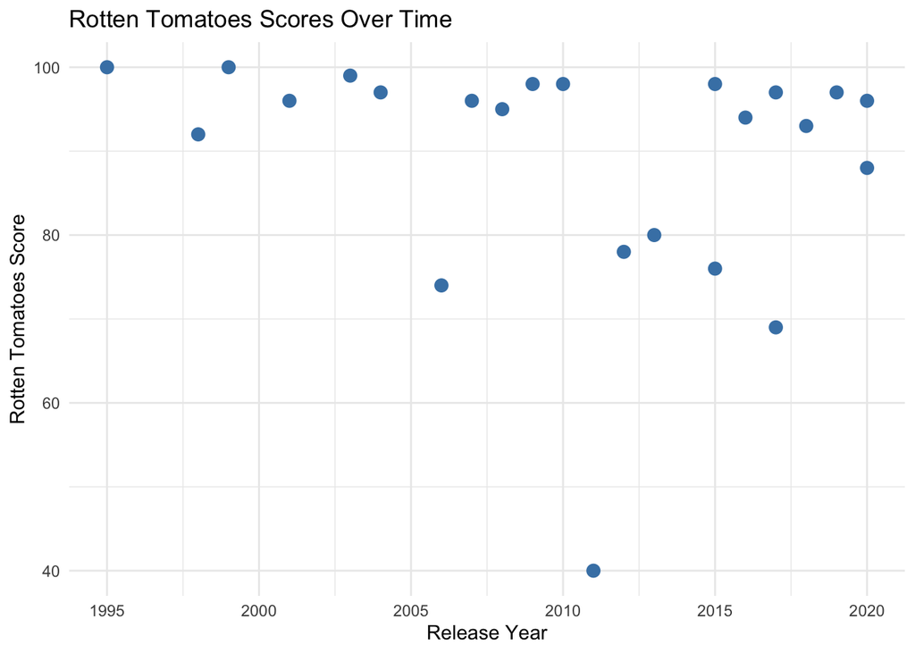

```r
ggplot(pixar_eda, aes(x = release_year, y = rotten_tomatoes)) +
  geom_point(size = 3, color = "steelblue") +
  labs(
    title = "Rotten Tomatoes Scores Over Time",
    x = "Release Year",
    y = "Rotten Tomatoes Score"
  ) +
  theme_minimal()
```

The scatterplot shows that Pixar’s earliest films were consistently highly rated, with all films before 2006 scoring above 90. From 2006 onwards scores become more variable: the two clear low outliers are *Cars 2* (2011, score 40) and *Cars 3* (2017, score 69), while several later films such as *Inside Out*, *Coco* and *Soul* still score above 95.

Chart 3: Average Profit by Era We create this chart to compare the financial performance of Pixar films across the three eras.

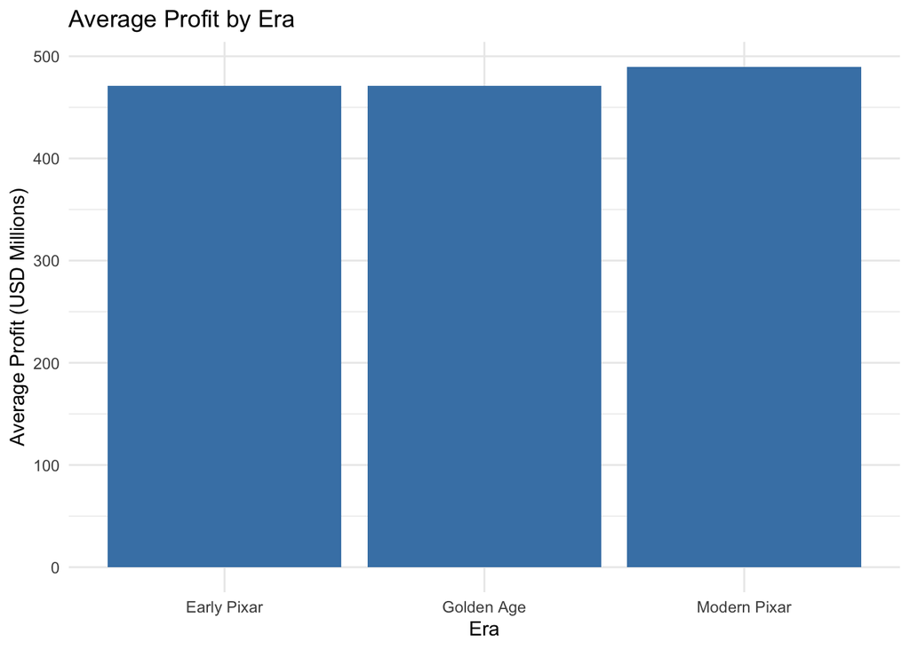

```r
pixar_eda %>%
  group_by(era) %>%
  summarise(avg_profit = mean(profit, na.rm = TRUE)) %>%
  ggplot(aes(x = era, y = avg_profit / 1000000)) +
  geom_col(fill = "steelblue") +
  labs(
    title = "Average Profit by Era",
    x = "Era",
    y = "Average Profit (USD Millions)"
  ) +
  theme_minimal()
```

The bar chart confirms what we found in the grouped summary — average profit is remarkably consistent across all three eras, ranging between $470 and $490 million. This suggests Pixar has maintained a stable level of commercial success throughout its history.

Chart 4: ROI by Budget Category We create this chart to explore whether films with lower budgets tend to deliver better returns on investment.

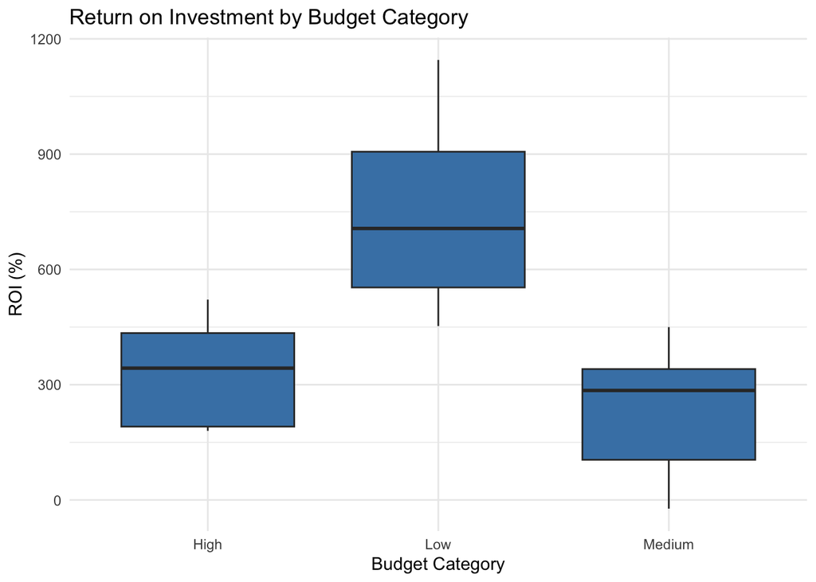

```r
ggplot(pixar_eda, aes(x = budget_category, y = roi)) +
  geom_boxplot(fill = "steelblue") +
  labs(
    title = "Return on Investment by Budget Category",
    x = "Budget Category",
    y = "ROI (%)"
  ) +
  theme_minimal()
```

The boxplot shows that low budget films achieved the highest median ROI (about 707%), with a wide spread indicating that some films in this category performed exceptionally well relative to their cost (*Toy Story* reached 1145%).

High and medium budget films show lower returns (median ROI about 343% and 285%), suggesting that bigger budgets do not necessarily lead to better financial efficiency. The medium category contains the two loss-making films, *Onward* and *Soul*.

This comparison should be read with care: the low budget group contains only 4 films, all from the Early Pixar era (1995–2004), and budgets are not adjusted for inflation. The difference therefore partly reflects the era rather than budget size alone.

Chart 5: Budget vs Worldwide Box Office We create this chart to explore whether films with higher budgets tend to earn more at the box office.

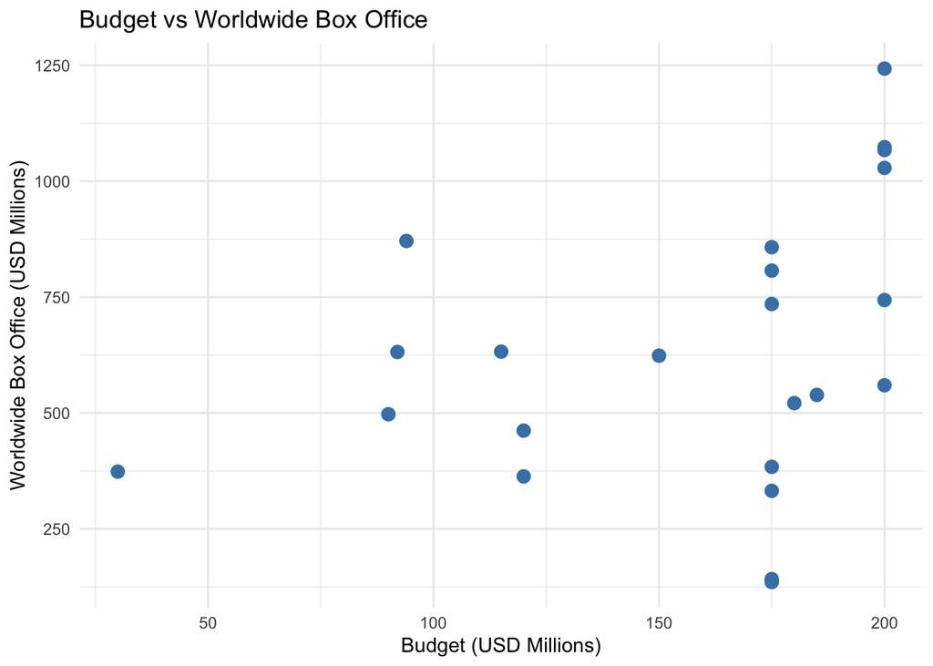

```r
ggplot(pixar_eda, aes(x = budget / 1000000, y = box_office_worldwide / 1000000)) +
  geom_point(size = 3, color = "steelblue") +
  labs(
    title = "Budget vs Worldwide Box Office",
    x = "Budget (USD Millions)",
    y = "Worldwide Box Office (USD Millions)"
  ) +
  theme_minimal()
```

The scatterplot shows a positive but weak relationship between budget and worldwide box office revenue (correlation ≈ 0.34) — films with higher budgets tend to earn somewhat more, but there is a lot of variation at every budget level.

Two $175 million films clearly underperformed at the box office, earning less than their budget: *Onward* and *Soul*, which we identified earlier as the pandemic-affected releases.

Chart 6: Profit Comparison Between Sequels and Original Films We create this chart to compare the financial performance of sequels versus original films.

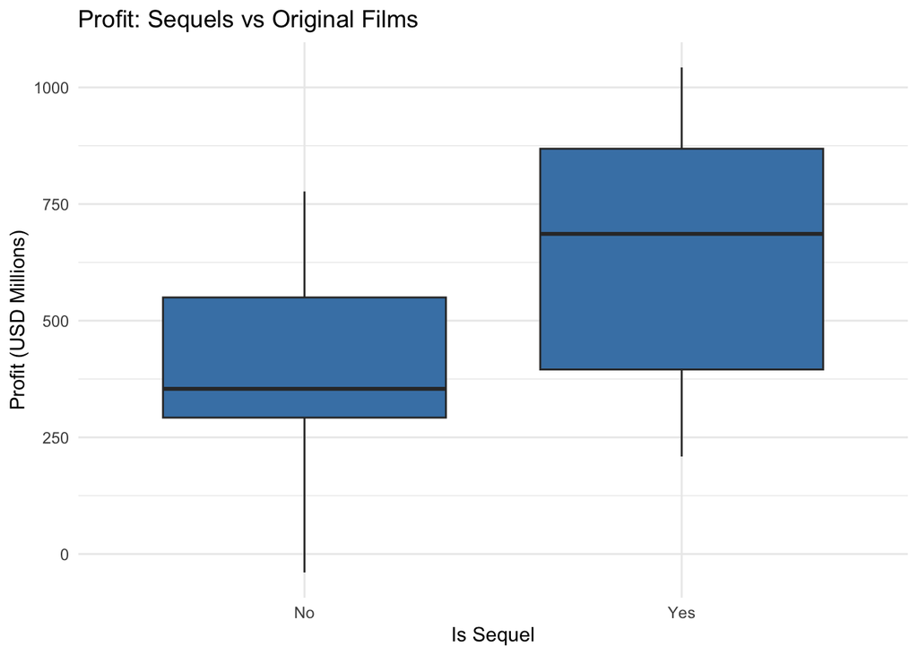

```r
ggplot(pixar_eda, aes(x = is_sequel, y = profit / 1000000)) +
  geom_boxplot(fill = "steelblue") +
  labs(
    title = "Profit: Sequels vs Original Films",
    x = "Is Sequel",
    y = "Profit (USD Millions)"
  ) +
  theme_minimal()
```

The boxplot confirms that sequels tend to generate higher profits than original films, with a clearly higher median (about $686 million vs $354 million). Sequels also show a wide spread, from *Cars 3* (about $209 million) to *Incredibles 2* (over $1 billion).

Original films extend lower, reaching below zero with the two loss-making films *Onward* and *Soul* at the bottom of the chart.

All sequels in the dataset made a positive profit, while original films show more financial risk. With only 8 sequels, however, this pattern should not be over-interpreted.

Chart 7: Distribution of Film Ratings We create this chart to see how Pixar films are distributed across rating categories.

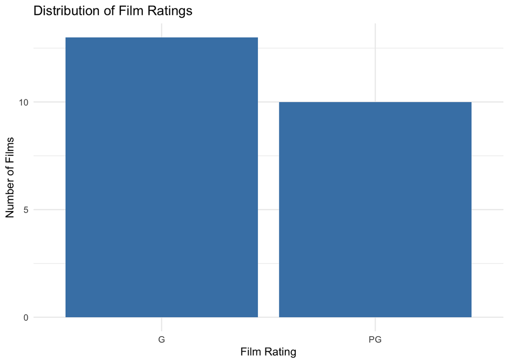

```r
ggplot(pixar_eda, aes(x = film_rating)) +
  geom_bar(fill = "steelblue") +
  labs(
    title = "Distribution of Film Ratings",
    x = "Film Rating",
    y = "Number of Films"
  ) +
  theme_minimal()
```

The bar chart shows that Pixar films are fairly evenly split between G and PG ratings, with G films slightly more common (13 G vs 10 PG).

Chart 8: Distribution of Film Runtime We create this chart to understand how Pixar film lengths are distributed.

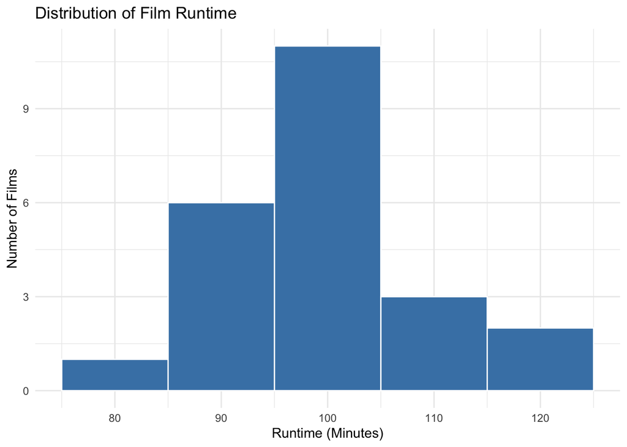

```r
ggplot(pixar_eda, aes(x = run_time)) +
  geom_histogram(binwidth = 10, fill = "steelblue", color = "white") +
  labs(
    title = "Distribution of Film Runtime",
    x = "Runtime (Minutes)",
    y = "Number of Films"
  ) +
  theme_minimal()
```

- Most films fall between 85 and 105 minutes — 17 of the 23 films are in this range - The peak is the 95–105 minute bin with 11 films - Only one film is noticeably shorter (*Toy Story*, 81 minutes) and only two are longer than 115 minutes (*Cars*, 117 and *Incredibles 2*, 118)

Chart 9: Average Critic Score by Era We create this chart to compare how critical reception has changed across Pixar’s three eras.

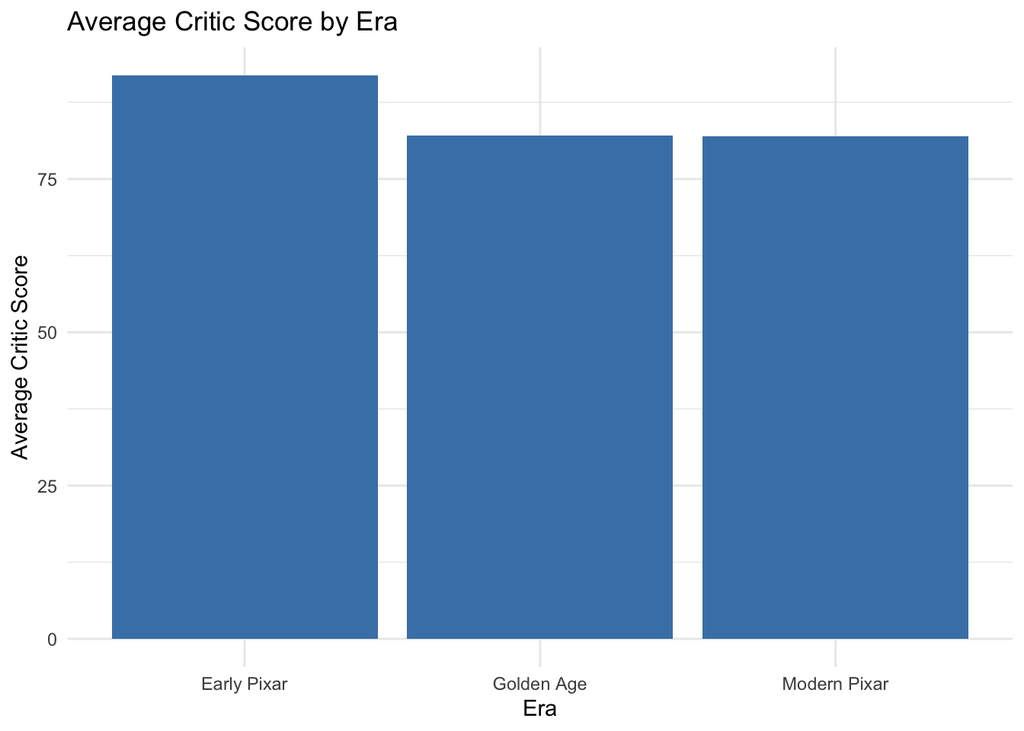

```r
pixar_eda %>%
  group_by(era) %>%
  summarise(mean_critic_score = mean(avg_critic_score, na.rm = TRUE)) %>%
  ggplot(aes(x = era, y = mean_critic_score)) +
  geom_col(fill = "steelblue") +
  labs(
    title = "Average Critic Score by Era",
    x = "Era",
    y = "Average Critic Score"
  ) +
  theme_minimal()
```

The bar chart shows that Early Pixar films had the highest average critic scores.

It is worth noting that all three eras still average above 75, meaning Pixar has consistently produced well reviewed films throughout its history — the differences between eras are real but not dramatic.

Chart 10: Rotten Tomatoes vs Metacritic Scores We create this chart to explore the relationship between two different critic score sources.

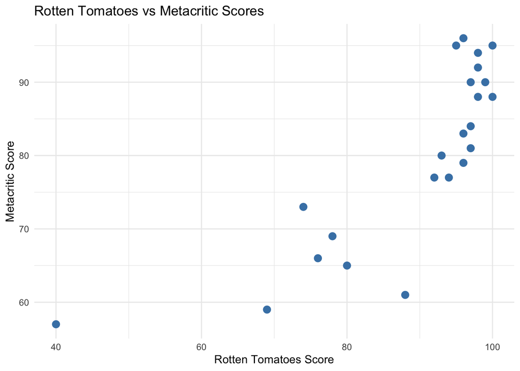

```r
ggplot(pixar_eda, aes(x = rotten_tomatoes, y = metacritic)) +
  geom_point(size = 3, color = "steelblue") +
  labs(
    title = "Rotten Tomatoes vs Metacritic Scores",
    x = "Rotten Tomatoes Score",
    y = "Metacritic Score"
  ) +
  theme_minimal()
```

The scatterplot shows a positive relationship between Rotten Tomatoes and Metacritic scores.

Metacritic scores are generally lower than Rotten Tomatoes scores, and the outlier in the bottom left shows a film that scored poorly on both platforms.

Overall, the EDA reveals that Pixar films are generally profitable and well reviewed. Early films had the highest critic scores and ROI, sequels earn more than originals in absolute terms (but not in ROI), and higher budgets tend to go together with somewhat higher box office revenue. These findings will guide our modeling section.

## 4. Modeling

In this section we build two statistical models to answer specific analytical questions about Pixar films.

**Question 1:** Can we predict a Pixar film’s worldwide box office revenue based on its budget and critic scores? We will use **linear regression** to answer this question, as we are predicting a continuous numeric outcome.

**Question 2:** Can we predict whether a Pixar film will be commercially successful based on its budget, critic scores and runtime? We will use **logistic regression** to answer this question, as the outcome is binary — a film either made a profit (Yes) or did not (No).

### 4.1 Linear Regression: Predicting Worldwide Box Office Revenue

We use linear regression to predict box_office_worldwide based on budget, rotten_tomatoes, and metacritic. These predictors were chosen because our EDA showed a positive relationship between budget and box office revenue, and critic scores are central to our research question about critical acclaim and financial performance.

```r
# Set seed
set.seed(314)

# Split data into training (75%) and testing (25%)
pixar_split <- initial_split(pixar_eda, prop = 0.75)

pixar_training <- training(pixar_split)
pixar_test <- testing(pixar_split)

cat("Training set:", nrow(pixar_training), "films\n")
```

```
## Training set: 17 films
```

```r
cat("Testing set:", nrow(pixar_test), "films\n")
```

```
## Testing set: 6 films
```

Since our dataset is small (23 films), the training set contains 17 films and the testing set contains 6.

This is a limitation of this dataset when evaluating the model: with only 6 test films, the test metrics depend heavily on which films happen to land in the test set.

```r
lm_model_spec <- linear_reg() %>%
  set_engine("lm") %>%
  set_mode("regression")


lm_fit <- lm_model_spec %>%
  fit(box_office_worldwide ~ budget + rotten_tomatoes + metacritic,
      data = pixar_training)

summary(lm_fit$fit)
```

```
##
## Call:
## stats::lm(formula = box_office_worldwide ~ budget + rotten_tomatoes +
##     metacritic, data = data)
##
## Residuals:
##        Min         1Q     Median         3Q        Max
## -302018899 -138653686   -3083125   70236243  384708291
##
## Coefficients:
##                   Estimate Std. Error t value Pr(>|t|)
## (Intercept)     -1.348e+09  4.957e+08  -2.719   0.0176 *
## budget           4.380e+00  1.173e+00   3.734   0.0025 **
## rotten_tomatoes -1.328e+06  5.726e+06  -0.232   0.8202
## metacritic       1.817e+07  7.202e+06   2.522   0.0255 *
## ---
## Signif. codes:  0 '***' 0.001 '**' 0.01 '*' 0.05 '.' 0.1 ' ' 1
##
## Residual standard error: 210300000 on 13 degrees of freedom
## Multiple R-squared:  0.5815, Adjusted R-squared:  0.4849
## F-statistic: 6.021 on 3 and 13 DF,  p-value: 0.008429
```

The `budget` coefficient has a p-value of 0.0025, which is well below 0.05, meaning it is statistically significant in the training data. The estimate of 4.38 means that, holding critic scores constant, each extra dollar of budget is associated with approximately $4.38 more at the worldwide box office. This is an association, not a causal effect — bigger budgets also tend to go to franchise films and sequels.

The `metacritic` coefficient has a p-value of 0.0255, which is just below 0.05, meaning it is also statistically significant. The estimate of 18,170,000 means that each additional point on the Metacritic scale is associated with around $18 million more in worldwide revenue.

The `rotten_tomatoes` coefficient has a p-value of 0.82, which is far above 0.05, meaning it is not statistically significant. We cannot conclude that Rotten Tomatoes score has a meaningful effect on box office revenue when budget and Metacritic are already included in the model.

The R-squared value of 0.58 means the model explains 58% of the variation in worldwide box office revenue in the training data (adjusted R-squared 0.48, which accounts for the number of predictors). The overall F-test (F = 6.02 on 3 and 13 degrees of freedom, p = 0.008) indicates the model as a whole is statistically significant. With only 17 training films, however, these estimates are fragile.

```r
# Predictions
lm_predictions <- lm_fit %>%
  predict(new_data = pixar_test) %>%
  bind_cols(pixar_test %>% select(movie_title, box_office_worldwide))

# View predictions vs actual values
lm_predictions
```

```
## # A tibble: 6 × 3
##         .pred movie_title    box_office_worldwide
##         <dbl> <chr>                         <dbl>
## 1  463626155. Monsters, Inc.            632316649
## 2 1040315331. WALL-E                    521311860
## 3  398990893. Cars 3                    383930656
## 4  761444093. Coco                      807082196
## 5  925446343. Toy Story 4              1073394593
## 6  799102636. Soul                      135435315
```

```r
# Performance metrics
metrics(lm_predictions,
        truth = box_office_worldwide,
        estimate = .pred)
```

```
## # A tibble: 3 × 3
##   .metric .estimator .estimate
##   <chr>   <chr>          <dbl>
## 1 rmse    standard     3.56e+8
## 2 rsq     standard     6.47e-2
## 3 mae     standard     2.60e+8
```

When we evaluate the model on the 6 test films, the results are weaker than on the training data. The R-squared drops from 0.58 on the training set to just 0.065 on the test set, meaning the model explains very little of the variation in box office revenue for unseen films.

The RMSE is about $356 million and the MAE about $260 million, meaning a typical prediction is off by several hundred million dollars. The large gap between training and test performance is likely due to two reasons — the very small dataset of only 23 films makes it difficult to build a reliable model, and *Soul* is an extreme outlier in the test set: the model predicted about $799 million, while it earned only $135 million because it skipped US cinemas during the pandemic. *WALL-E* was also heavily over-predicted (about $1.04 billion predicted vs $521 million actual).

These results highlight the limitations of modeling with such a small dataset.

### 4.2 Logistic Regression: Predicting Commercial Success

We use logistic regression to predict whether a Pixar film will be commercially successful — meaning it made a profit. The outcome variable is `commercial_success` (Yes or No), which we created during the EDA stage.

We use `budget`, `rotten_tomatoes`, `metacritic`, and `run_time` as predictors. Logistic regression is appropriate here because the outcome is binary rather than numeric.

```r
# Prepare the data
pixar_log <- pixar_eda %>%
  mutate(commercial_success = as.factor(commercial_success))

# Check factor levels
levels(pixar_log$commercial_success)
```

```
## [1] "No"  "Yes"
```

```r
# Reorder so "Yes" is the first level (positive class)
pixar_log <- pixar_log %>%
  mutate(commercial_success = factor(commercial_success, levels = c("Yes", "No")))

# Confirm the order
levels(pixar_log$commercial_success)
```

```
## [1] "Yes" "No"
```

```r
# Split the data
set.seed(314)

log_split <- initial_split(pixar_log, prop = 0.75, strata = commercial_success)

log_training <- training(log_split)
log_test <- testing(log_split)

cat("Training set:", nrow(log_training), "films\n")
```

```
## Training set: 17 films
```

```r
cat("Testing set:", nrow(log_test), "films\n")
```

```
## Testing set: 6 films
```

```r
# Define logistic regression model specification
log_model_spec <- logistic_reg() %>%
  set_engine("glm") %>%
  set_mode("classification")

# Train the model
log_fit <- log_model_spec %>%
  fit(commercial_success ~ budget + rotten_tomatoes + metacritic + run_time,
      data = log_training)

# View
summary(log_fit$fit)
```

```
##
## Call:
## stats::glm(formula = commercial_success ~ budget + rotten_tomatoes +
##     metacritic + run_time, family = stats::binomial, data = data)
##
## Coefficients:
##                   Estimate Std. Error z value Pr(>|z|)
## (Intercept)     -3.114e+01  6.748e+01  -0.461    0.644
## budget           1.770e-08  3.534e-08   0.501    0.616
## rotten_tomatoes  4.186e-01  9.198e-01   0.455    0.649
## metacritic      -1.660e-01  5.191e-01  -0.320    0.749
## run_time        -2.468e-03  1.907e-01  -0.013    0.990
##
## (Dispersion parameter for binomial family taken to be 1)
##
##     Null deviance: 7.6064  on 16  degrees of freedom
## Residual deviance: 5.9411  on 12  degrees of freedom
## AIC: 15.941
##
## Number of Fisher Scoring iterations: 9
```

The logistic regression results show that none of the predictors — `budget`, `rotten_tomatoes`, `metacritic`, or `run_time` — are statistically significant, as all p-values are well above 0.05.

This means we cannot reliably predict commercial success from these variables. However this result is not surprising given the nature of the data — almost all Pixar films in our dataset made a profit, with only two exceptions (*Onward* and *Soul*). After the stratified split, only one of them (*Soul*) is in the training set, so the model is fitted on 16 “Yes” films and a single “No” film. When nearly all outcomes are the same (Yes), the model has very little variation to learn from, making it very difficult to identify meaningful predictors. The residual deviance (5.94) is only slightly lower than the null deviance (7.61), confirming that the predictors add very little information.

Note on interpretation: because “Yes” is set as the first factor level, `glm()` models the probability of the *second* level, “No”. The coefficient signs above therefore describe the log-odds of a film **not** being commercially successful. `parsnip` takes this into account automatically when producing `.pred_Yes` and `.pred_No`, so the predictions below are correct.

```r
# Predictions

log_predictions <- log_fit %>%
  predict(new_data = log_test) %>%
  bind_cols(log_fit %>%
              predict(new_data = log_test, type = "prob")) %>%
  bind_cols(log_test %>% select(movie_title, commercial_success))

# View
log_predictions
```

```
## # A tibble: 6 × 5
##   .pred_class .pred_Yes .pred_No movie_title    commercial_success
##   <fct>           <dbl>    <dbl> <chr>          <fct>
## 1 Yes             0.905   0.0945 Monsters, Inc. Yes
## 2 Yes             0.985   0.0148 WALL-E         Yes
## 3 Yes             0.891   0.109  Toy Story 3    Yes
## 4 Yes             0.946   0.0543 Inside Out     Yes
## 5 Yes             0.758   0.242  Coco           Yes
## 6 Yes             0.830   0.170  Onward         No
```

```r
# performance metrics
accuracy(log_predictions,
         truth = commercial_success,
         estimate = .pred_class)
```

```
## # A tibble: 1 × 3
##   .metric  .estimator .estimate
##   <chr>    <chr>          <dbl>
## 1 accuracy binary         0.833
```

The model correctly predicted 5 out of 6 films, achieving an accuracy of 83.3%. However this result should be interpreted carefully. The model predicted “Yes” for every single film, which means it did not actually learn to distinguish between successful and unsuccessful films — it simply defaulted to the majority class. *Onward*, the only unprofitable film in the test set, was the only film predicted incorrectly. In other words, the model never correctly identified a loss-making film (sensitivity for the “No” class is 0%), and a naive rule of always predicting “Yes” would achieve exactly the same 83.3% accuracy.

This confirms what we saw in the coefficients — with almost all films being commercially successful, the model has very little to learn from and the high accuracy is misleading rather than meaningful.

### 4.3 Model Comparison

We built two models to answer our analytical questions. Here we compare them across several dimensions.

Statistical significance: In the linear regression model, budget and metacritic were statistically significant predictors on the training data. In the logistic regression model, none of the predictors were statistically significant.

Limitations: Both models are heavily limited by the small dataset of only 23 films. With so few observations, it is difficult to build reliable models that generalize well to new data. The logistic regression was further limited by class imbalance — only 2 of 23 films lost money, leaving very little variation for the model to learn from.

Conclusion: Between the two models, linear regression produced more meaningful results. It identified budget and Metacritic score as significant predictors of box office revenue in the training data, which aligns with our EDA findings. However, its weak test performance (R-squared = 0.065) shows that these relationships do not yet translate into reliable predictions for new films. The logistic regression was not able to produce useful predictions given the nature of the data.

## 5. Summary and Reflection

### 5.1 Project Summary and Main Findings

In this project, we analyzed the Pixar Film Ratings dataset to explore the relationship between critical acclaim, budget, and commercial success. We successfully integrated three distinct tables into a clean Master Dataset, engineered 10 new variables (such as `profit`, `roi`, `era`, and `is_sequel`), and visualized key industry trends.

Our main findings indicate that while early Pixar films achieved the highest critical scores and Return on Investment (ROI), the studio has maintained remarkably consistent average absolute profit (around $470–490 million per film) across all its eras. Furthermore, in our linear regression model, production budget and Metacritic score were statistically significant predictors of a film’s worldwide box office revenue on the training data — although the model did not generalise well to the test films.

### 5.2 Difficulties and Limitations

The most difficult part of the project was building reliable predictive models. Our dataset was extremely small (only 23 films after cleaning), which severely limited our models’ ability to generalize. This was evident in our linear regression model, which fit the training data well but performed poorly on the test set.

Additionally, modeling commercial success using logistic regression was highly challenging due to extreme class imbalance. Because almost every Pixar film in history has been profitable, the model had almost no “unsuccessful” examples to learn from, resulting in a misleadingly high accuracy where the model simply predicted “Yes” for everything. Finally, dealing with outliers — specifically the pandemic-era films *Onward* and *Soul*, which had unusual release contexts and were the only two unprofitable films — significantly skewed our test predictions (*Soul* in the linear model, *Onward* in the logistic model).

### 5.3 Reflection and Future Improvements

The most interesting part of the analytical process was discovering the financial dynamics of sequels versus original films. It was fascinating to see that while sequels generated higher absolute profits in our data (possibly helped by established fanbases), their actual financial efficiency (ROI) is almost identical to riskier original films, because they also cost more to make.

If we were to start this project again, or if we had more time and resources, we would not limit ourselves to just Pixar. We would expand our dataset to include all Walt Disney Animation Studios and DreamWorks Animation films. This would dramatically increase our sample size, introduce a balanced mix of profitable and unprofitable films for our logistic regression, and allow us to build much more robust and trustworthy machine learning models.